# Bee Data Monte Carlo Group 2

Vasiliy Ostapenko (vostapenko) Arthur Starodynov (astarodynov) Jake Bentley (williambentley)

### Useful Links for Background Knowledge:

- [Link 1](https://letianzj.github.io/mcmc-linear-regression.html)
- [Link 2](https://towardsdatascience.com/bootstrap-sampling-in-r-a7bc9d3ca14a)
- [Link 3](https://en.wikipedia.org/wiki/Linear_regression)

## Abstract

In this paper, we use Monte Carlo methods for parameter estimation in the context of a linear regression model of bee wing vein density on bee body size. Concretely, we use a dataset of 48 bee samples, fit a simple linear regression model (y = b0 + b1*x) to estimate b1 (the slope), and then compare that estimate with those obtained from bootstrapping and Markov chain Monte Carlo, respectively. We are interested in this analysis because we seek to determine whether the slope parameter for the model is significant (nonzero). We first obtained an OLS estimate for b1, which was nonzero. We then used Monte Carlo resampling (bootstrapping) with varying sample sizes to build several confidence intervals for b1. Finally, using MCMC, we built another sampling distribution of b1. We found that, with a large enough sample size, both Monte Carlo methods produced estimates which were significant (nonzero), agreeing with the OLS estimate. These results matter, because we now know that we have significant impact on the response from the predictor variable.

## Introduction

The motivation for this project came from wanting to extend the research of a fellow UCSB student, whose dataset we used. In his studies, he collected 48 bee samples, observing both categorical and numeric parameters. He then fit a simple linear regression model of vein density on body size, hypothesizing that there was a linear relationship between the two variables. The resulting low R-squared made us question whether there was indeed a significant relationship. Being in a computational statistics course, we wanted to move beyond a t-test for slope or a nested model F-test, and thus chose two Monte Carlo methods for estimating the slope parameter. In particular, we were acutely interested in whether it is significant (nonzero).

```r
df = read.csv("./data/bee_data.csv") # load the data
df$Ratio = 100 * df$Ratio # scale response by 100 to avoid small decimals
```

## Methods

The first method we used to analyze the data and gain a baseline estimate for b1 was fitting a simple linear regression model and computing the slope through OLS. A simple linear regression model assumes that the response is a linear function of the predictors as well as noise, which follows a normal distribution. Concretely, in our implementation, we used the glm() function and specified the Gaussian family due to our data being continuous and unbounded. Once the model was fit, we obtained a nonzero estimate for b1. However, due to the low R-squared, we decided to explore the data further. It was clear that there were a few outliers in the data based on the Cook’s distance criterion. Thus, we fit another linear regression model to the data without the outliers. Finally, we got a slightly better R-squared and a nonzero estimate for b1, still. We now decided to explore how these results stacked up to computational estimates.

```r
mod = glm(formula=Ratio ~ IT, family="gaussian", data=df) # fit simple OLS model
summary(mod)
```

```
##
## Call:
## glm(formula = Ratio ~ IT, family = "gaussian", data = df)
##
## Deviance Residuals:
##    Min      1Q  Median      3Q     Max
## -3.365  -0.720  -0.047   0.911   3.004
##
## Coefficients:
##             Estimate Std. Error t value Pr(>|t|)
## (Intercept)   13.754      0.376   36.54   <2e-16 ***
## IT             0.418      0.129    3.24   0.0023 **
## ---
## Signif. codes:  0 '***' 0.001 '**' 0.01 '*' 0.05 '.' 0.1 ' ' 1
##
## (Dispersion parameter for gaussian family taken to be 2.016)
##
##     Null deviance: 113.810  on 47  degrees of freedom
## Residual deviance:  92.715  on 46  degrees of freedom
## AIC: 173.8
##
## Number of Fisher Scoring iterations: 2
```

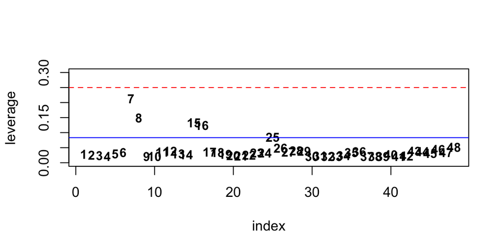

```r
lev = hatvalues(mod) # compute leverages

n = nrow(df)
p = 3
dat = data.frame(index=seq(length(lev)), leverage=lev)
plot(leverage~index, col="white", data=dat, pch=NULL, ylim=c(0, 0.3))
text(leverage~index, labels=index, data=dat, cex=0.9, font=2)
abline(h=(p+1)/n, col="blue")
abline(h=3*(p+1)/n, col="red", lty=2)
```

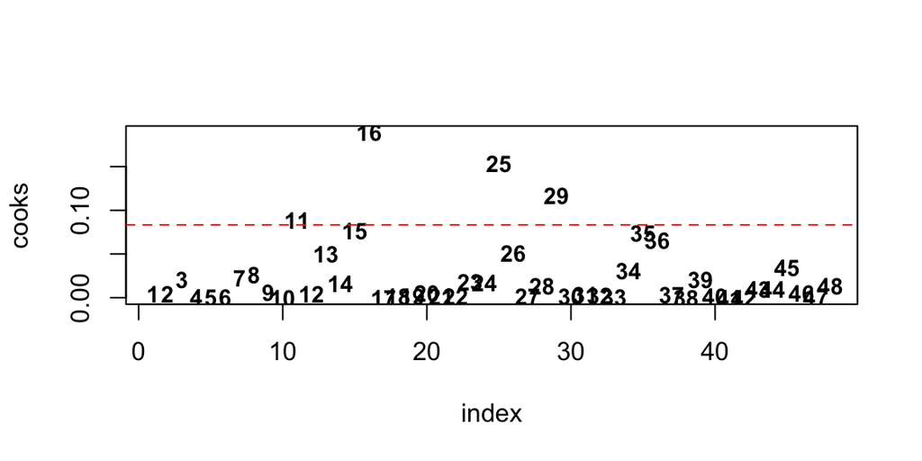

```r
d = cooks.distance(mod) # compute Cook's distance measure

dat2 = data.frame(index=seq(length(d)), cooks=d)
plot(cooks~index, col="white", data=dat2, pch=NULL)
text(cooks~index, labels=index, data=dat2, cex=0.9, font=2)
abline(h=4/n, col="red", lty=2)
```

```r
# simple OLS fit to data without outliers
mod2 = glm(formula=Ratio ~ IT, family="gaussian", data=df[-c(11, 16, 25, 29), ])
```

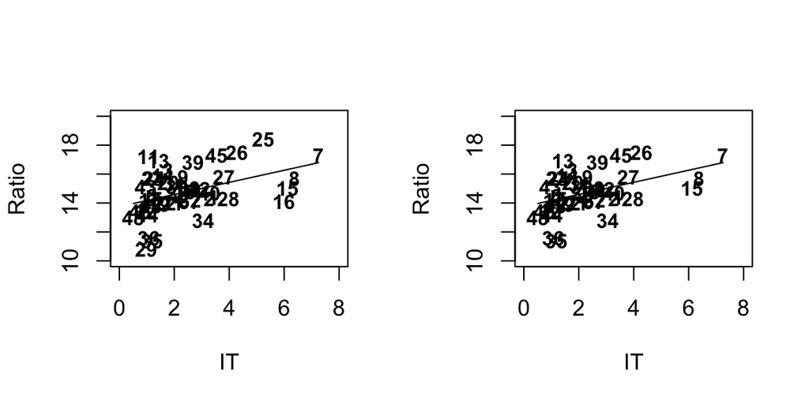

```r
par(mfrow=c(1, 2))
{
  {
    plot(Ratio~IT, data=df, col="white", pch=NULL,
         xlim=c(0, 8), ylim=c(10, 20))
    text(Ratio~IT, labels=rownames(df), data=df,
         cex=0.9, font=2)
    lines(x=df$IT, y=predict(mod, df))
  }
  {
    plot(Ratio~IT, data=df[-c(11, 16, 25, 29), ], col="white", pch=NULL,
         xlim=c(0, 8), ylim=c(10, 20))
    text(Ratio~IT, labels=rownames(df[-c(11, 16, 25, 29), ]), data=df[-c(11, 16, 25, 29), ],
         cex=0.9, font=2)
    lines(x=df[-c(11, 16, 25, 29), ]$IT, y=predict(mod2, df[-c(11, 16, 25, 29), ]))
  }
}
```

```r
print(paste0("mod R2: ", round(1 - mod$deviance/mod$null.deviance, 3)))
```

```
## [1] "mod R2: 0.185"
```

```r
print(paste0("mod2 R2: ", round(1 - mod2$deviance/mod2$null.deviance, 3)))
```

```
## [1] "mod2 R2: 0.214"
```

```r
boot_sim = function(nboot=10000, bootsizes=c(15, 20, 25, 30)) {
  container = list()
  j = 1
  for(bootsize in bootsizes) {
    b0_estimates = vector(mode="numeric", length=nboot)
    b1_estimates = vector(mode="numeric", length=nboot)
    for(i in seq(nboot)) {
      bdat = df[sample(nrow(df), size=bootsize, replace=TRUE), ]
      bfit = update(mod, data=bdat) # update model with new sample
      b0_estimates[i] = coef(bfit)[[1]]
      b1_estimates[i] = coef(bfit)[[2]]
    }
    results = list(size=bootsize,
                   b0_mu=mean(b0_estimates), b0_se=sd(b0_estimates),
                   b1_mu=mean(b1_estimates), b1_se=sd(b1_estimates))
    container[[j]] = results
    j = j+1
  }
  container = rbindlist(container)
  return(container)
}

data = boot_sim() # generate simulated data
```

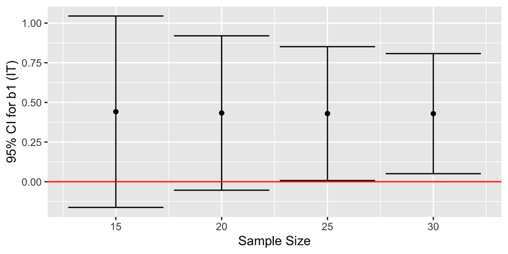

```r
p = ggplot(data, aes(size, b1_mu)) +
  geom_point() +
  geom_errorbar(aes(ymin=b1_mu-1.96*b1_se, ymax=b1_mu+1.96*b1_se)) +
  geom_hline(yintercept=0, col="red") +
  labs(y="95% CI for b1 (IT)", x="Sample Size")

p
```

The AR step requires a proposal function, which we set to a normal distribution with variance 0.25 and means b0 and b1, respectively. Each transition of the Markov chain, we calculate our proposal given our previous state. Then, we calculate our acceptance ratio, using our posterior probability given our proposal minus our posterior probability given the previous step. We thus get the probability of accepting the proposal as the next state or rejecting this value and not transitioning in the next time-step. We repeat this ten thousand times to generate, after about two thousand steps, a distribution for b0 and b1. Finally, we can obtain an estimate for b1 by simply taking an average.

```r
prior_probability = function(beta) {
  a = beta[1]
  b = beta[2]
  a_prior = dunif(a, min=0, max=30) # naively assume uniform prior
  b_prior = dunif(b, min=0, max=1)
  return(log(a_prior)+log(b_prior))
}

likelihood_probability = function(beta, x, y) {
  a = beta[1]
  b = beta[2]
  y_predict = a+b*x
  single_likelihoods = dnorm(x=y, mean=y_predict, sd=3.0)
  return(sum(log(single_likelihoods)))
}

posterior_probability = function(beta, x, y) {
  return( likelihood_probability(beta, x, y) + prior_probability(beta) )
}

proposal_function = function(beta) {
  a = beta[1]
  b = beta[2]
  a_new = rnorm(n=1, mean=a, sd=0.5)
  b_new = rnorm(n=1, mean=b, sd=0.5)
  beta_new = c(a_new, b_new)
  return(beta_new)
}

mcmc_sim = function(x, y, n=10000) {
  container = data.frame(b0=vector(mode="numeric", length=n),
                         b1=vector(mode="numeric", length=n))
  beta_0 = c(0.5, 0.5)
  container[1, ] = beta_0

  for(step in 2:n) {
    beta_old = as.numeric(container[step-1, ])
    beta_proposal = proposal_function(beta_old)

    prob = exp(posterior_probability(beta_proposal, x, y) -
                 posterior_probability(beta_old, x, y))

    u = runif(n=1, min=0, max=1)

    if(is.na(u < prob)) {
      container[step, ] = beta_old
    }
    else {
      if(u < prob) {
        container[step, ] = beta_proposal # MC transition to new state
      }
      else {
        container[step, ] = beta_old # MC stays in old state
      }
    }
  }
  return(container)
}

data2 = mcmc_sim(x=df$IT, y=df$Ratio, n=10000) # generate simulated data
```

```r
burn_in = 2000
beta_posterior = data2[burn_in:nrow(data2), ]
print(paste0("b0 estimate: ", round(mean(beta_posterior$b0), 3),
             "; b1 estimate: ",
             round(mean(beta_posterior$b1), 3)))
```

```
## [1] "b0 estimate: 13.624; b1 estimate: 0.462"
```

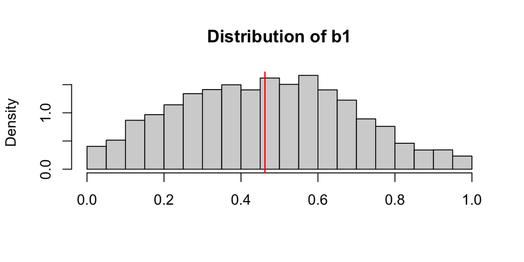

```r
{
  hist(beta_posterior$b1, breaks=30, freq=FALSE, xlab="",
       main=paste0("Distribution of b1"))
  abline(v=mean(beta_posterior$b1), col="red", lwd=1.5)
}
```